# Matplotlib (visualisation en 2D et 3D pour Python)

Librairie pour les représentations graphiques

```python
 #Pour intégrer les graphes à votre notebook, il suffit de faire
%matplotlib inline
```

```python
from jyquickhelper import add_notebook_menu
add_notebook_menu()
```

run previous cell, wait for 2 seconds

*Aparté*

Les librairies de visualisation en python se sont beaucoup développées ([10 plotting librairies](http://www.xavierdupre.fr/app/jupytalk/helpsphinx/2016/pydata2016.html)).

La référence reste [matplotlib](http://matplotlib.org/), et la plupart sont pensées pour être intégrées à ses objets (c'est par exemple le cas de [seaborn](https://stanford.edu/~mwaskom/software/seaborn/introduction.html), [mpld3](http://mpld3.github.io/), [plotly](https://plot.ly/) et [bokeh](http://bokeh.pydata.org/en/latest/)). Il est donc utile de commencer par se familiariser avec matplotlib.

[figure not shown]

## Introduction

Matplotlib est un module destiné à produire des graphiques de toute sorte (voir http://matplotlib.org/gallery.html pour une gallerie d’images produites avec Matplotlib). Il est l’outil complémentaire de *numpy* et *scipy* lorsqu’on veut faire de l’analyse de données. Un guide d’utilisation se trouve à l’adresse http://matplotlib.org/users/index.html .

```python
 import matplotlib.pyplot as plt
```

## Graphes simples

la fonction la plus simple est la fonction **plot** sour la forme plot(x,y) où *x* est un tableau d’abscisses et *y* le tableau des ordonnées associées

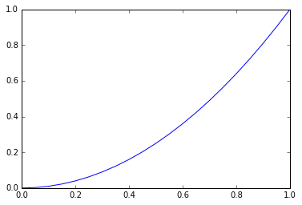

```python
x=np.linspace(0,1,21)
y=x*x
plt.plot(x,y)
plt.show()
```

### Plusieurs courbes en même temps

Il suffit de les ajouter les unes après les autres avant la commande plt.show().

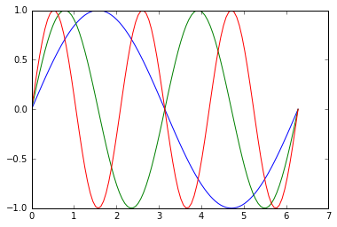

```python
x=np.linspace(0,2*np.pi,101)
plt.plot(x,np.sin(x))
plt.plot(x,np.sin(2*x))
plt.plot(x,np.sin(3*x))
plt.show()
```

De façon plus condensée, on peut le faire en une seule instruction

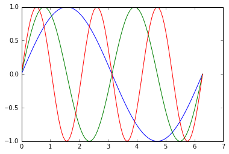

```python
x=np.linspace(0,2*np.pi,101)
plt.plot(x,np.sin(x),x,np.sin(2*x),x,np.sin(3*x))
plt.show()
```

### Couleurs, Marqueurs et styles de ligne

MatplotLib offre la possibilité d'adopter deux types d'écriture : chaîne de caractère condensée ou paramétrage explicite via un système clé-valeur.

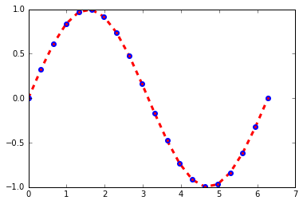

```python
x=np.linspace(0,2*np.pi,20)
plt.plot(x,np.sin(x), color='red', linewidth=3, linestyle="--", marker="o", markersize=5,
markeredgecolor="b", markeredgewidth=2)
plt.show()
```

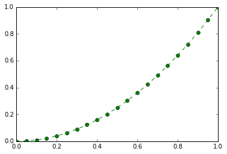

```python
x=np.linspace(0,1,21)
y=x*x
plt.plot(x,y,color='g',marker='o',linestyle='dashed')
# plt.show()
```

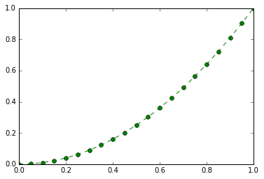

```python
x=np.linspace(0,1,21)
y=x*x
plt.plot(x,y,'og--') #l'ordre des paramètres n'importe pas
```

Plus de détails dans la documentation sur l'API de matplotlib pour paramétrer la [couleur](http://matplotlib.org/api/colors_api.html) , les [markers](http://matplotlib.org/api/markers_api.html) , et le [style des lignes](http://matplotlib.org/api/lines_api.html#matplotlib.lines.Line2D.set_linestyle) . MatplotLib est compatible avec plusieurs standards de couleur :

- sous forme d'une lettre : 'b' = blue (bleu), 'g' = green (vert), 'r' = red (rouge), 'c' = cyan (cyan), 'm' = magenta (magenta), 'y' = yellow (jaune), 'k' = black (noir), 'w' = white (blanc).
- sous forme d'un nombre entre 0 et 1 entre quotes qui indique le niveau de gris : par exemple '0.70' ('1' = blanc, '0' = noir).
- sous forme d'un nom : par exemple 'red'.
- sous forme html avec les niveaux respectifs de rouge (R), vert (G) et bleu (B) : '#ffee00'. Voici un site pratique pour récupérer une couleur en [RGB hexadécimal](http://www.proftnj.com/RGB3.htm).
- sous forme d'un triplet de valeurs entre 0 et 1 avec les niveaux de R, G et B : (0.2, 0.9, 0.1).

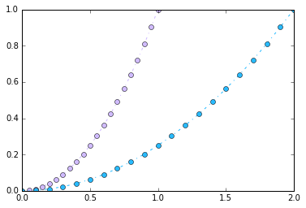

```python
x=np.linspace(0,1,21)
y=x*x

#avec la norme RGB
plt.plot(x,y,color='#D0BBFF',marker='o',linestyle='-.')
plt.plot(x*2,y,color=(0.156862745098039, 0.7333333333333333, 1.0),marker='o',linestyle='-.')
```

### Titre, légendes et labels

On peut également améliorer notre graphique en inserant :

```
- des étiquettes (abscisses et ordonnées) : $xlabel(texte), ylabel(texte)$
- une légende : $legend()$
- la grille : $grid()$
- titre du graphique : $title(texte) $
- un texte sur le graphique : $text(x,y,texte) $
- une grille en filligrane : $grid()$
```

Exemple :

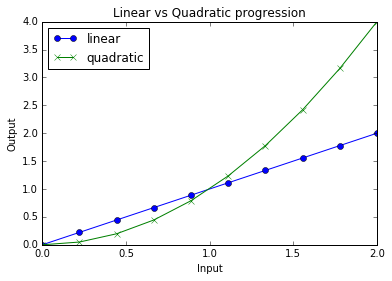

```python
x = np.linspace(0, 2, 10)

plt.plot(x, x, 'o-', label='linear')
plt.plot(x, x ** 2, 'x-', label='quadratic')

plt.legend(loc='best')
plt.title('Linear vs Quadratic progression')
plt.xlabel('Input')
plt.ylabel('Output');
plt.show()
```

### Ticks et axes

3 méthodes clés :

- xlim() : pour délimiter l'étendue des valeurs de l'axe
- xticks() : pour passer les graduations sur l'axe
- xticklabels() : pour passer les labels

Pour l'axe des ordonnées c'est ylim, yticks, yticklabels.

Pour récupérer les valeurs fixées :

- plt.xlim() ou plt.get_xlim()
- plt.xticks() ou plt.get_xticks()
- plt.xticklabels() ou plt.get_xticklabels()

Si vous voulez customiser les axes de plusieurs sous graphiques, passez par une [instance de axis](http://matplotlib.org/users/artists.html) et non subplot.

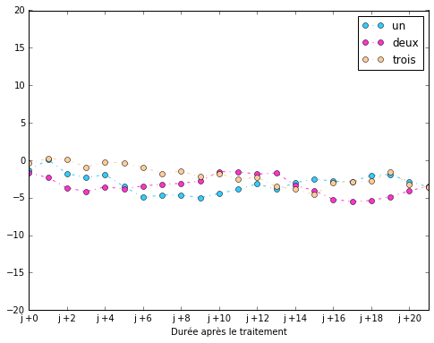

```python
from numpy.random import randn

fig = plt.figure(figsize=(8,6))
ax1 = fig.add_subplot(1,1,1)

serie1=randn(50).cumsum()
serie2=randn(50).cumsum()
serie3=randn(50).cumsum()
ax1.plot(serie1,color='#33CCFF',marker='o',linestyle='-.',label='un')
ax1.plot(serie2,color='#FF33CC',marker='o',linestyle='-.',label='deux')
ax1.plot(serie3,color='#FFCC99',marker='o',linestyle='-.',label='trois')

#sur le graphe précédent, pour raccourcir le range
ax1.set_xlim([0,21])
ax1.set_ylim([-20,20])

#faire un ticks avec un pas de 2 (au lieu de 5)
ax1.set_xticks(range(0,21,2))
#changer le label sur la graduation
ax1.set_xticklabels(["j +" + str(l) for l in range(0,21,2)])
ax1.set_xlabel('Durée après le traitement')

ax1.legend()
#permet de choisir l'endroit le plus vide
```

### Inclusion d'annotation et de texte, titre et libellé des axes

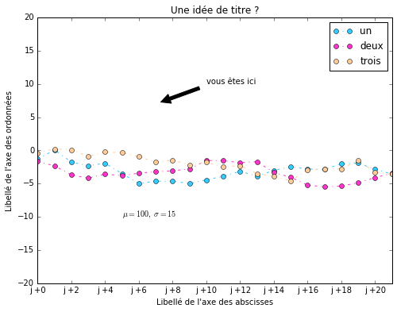

```python
from numpy.random import randn

fig = plt.figure(figsize=(8,6))
ax1 = fig.add_subplot(1,1,1)
ax1.plot(serie1,color='#33CCFF',marker='o',linestyle='-.',label='un')
ax1.plot(serie2,color='#FF33CC',marker='o',linestyle='-.',label='deux')
ax1.plot(serie3,color='#FFCC99',marker='o',linestyle='-.',label='trois')

ax1.set_xlim([0,21])
ax1.set_ylim([-20,20])
ax1.set_xticks(range(0,21,2))
ax1.set_xticklabels(["j +" + str(l) for l in range(0,21,2)])
ax1.set_xlabel('Durée après le traitement')

ax1.annotate("vous êtes ici ", xy=(7, 7), #point de départ de la flèche
             xytext=(10, 10),          #position du texte
            arrowprops=dict(facecolor='#000000', shrink=0.10),
            )

ax1.legend(loc='best')

plt.xlabel("Libellé de l'axe des abscisses")
plt.ylabel("Libellé de l'axe des ordonnées")
plt.title("Une idée de titre ?")
plt.text(5, -10, r'$\mu=100,\ \sigma=15$')

plt.show()
```

### matplotlib et le style

Il est possible de définir son propre style. Cette possibilité est intéressante si vous faîtes régulièrement les mêmes graphes et voulez définir des templates (plutôt que de copier/coller toujours les mêmes lignes de code). Tout est décrit [ici](http://matplotlib.org/users/style_sheets.html).

Une alternative consiste à utiliser des feuilles de styles pré-définies. Par exemple [ggplot](http://blog.yhat.com/posts/ggplot-for-python.html), librairie très utilisée sous R.

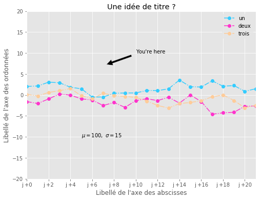

```python
from numpy.random import randn

#pour que la définition du style soit seulement dans cette cellule notebook
with plt.style.context('ggplot'):
    fig = plt.figure(figsize=(8,6))
    ax1 = fig.add_subplot(1,1,1)
    ax1.plot(serie1,color='#33CCFF',marker='o',linestyle='-.',label='un')
    ax1.plot(serie2,color='#FF33CC',marker='o',linestyle='-.',label='deux')
    ax1.plot(serie3,color='#FFCC99',marker='o',linestyle='-.',label='trois')

    ax1.set_xlim([0,21])
    ax1.set_ylim([-20,20])
    ax1.set_xticks(range(0,21,2))
    ax1.set_xticklabels(["j +" + str(l) for l in range(0,21,2)])
    ax1.set_xlabel('Durée après le traitement')

    ax1.annotate("You're here", xy=(7, 7), #point de départ de la flèche
                 xytext=(10, 10),          #position du texte
                arrowprops=dict(facecolor='#000000', shrink=0.10),
                )

    ax1.legend(loc='best')

    plt.xlabel("Libellé de l'axe des abscisses")
    plt.ylabel("Libellé de l'axe des ordonnées")
    plt.title("Une idée de titre ?")
    plt.text(5, -10, r'$\mu=100,\ \sigma=15$')

    #plt.show()
```

```
De nombreux autres styles sont disponibles, pick up your choice!  ['ggplot', 'seaborn-talk', 'seaborn-pastel', 'seaborn-poster', 'seaborn-white', 'seaborn-whitegrid', 'classic', 'seaborn-notebook', 'seaborn-dark-palette', 'seaborn-bright', 'seaborn-muted', 'seaborn-ticks', 'seaborn-colorblind', 'gra…
```

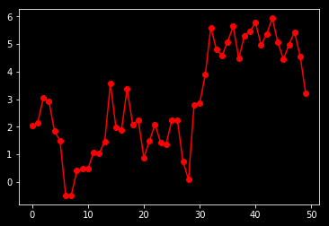

```python
import numpy as np
import matplotlib.pyplot as plt

print("De nombreux autres styles sont disponibles, pick up your choice! ", plt.style.available)
with plt.style.context('dark_background'):
    plt.plot(serie1, 'r-o')

# plt.show()
```

## Histogrammes

Un exemple est plus explicite

```
(1000,)
float64
[ 1.06759745  1.03491068  0.70978979  1.14455542  1.05632655  0.55368744
  0.65054342  1.27599392  0.63528282  1.34813689  0.93044227  0.45414687
  1.15454281  0.65403691  0.30176025  0.86619939  1.21113123  1.23835765
  0.09602027  0.82829144  1.27579593  0.59723022  1.59860618  0.9779493
  0.8512438   0.65961652  2.0626041   1.61572238  0.67057804  1.58228104]
```

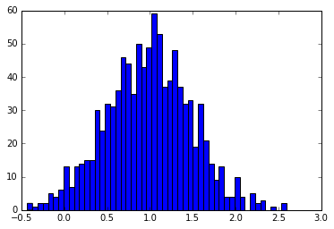

```python
# Gaussian, mean 1, stddev .5, 1000 elements
# on crée un tableau avec des valeurs aléatoires obtenues
# avec une loi normale
samples = np.random.normal(loc=1.0, scale=0.5, size=1000)
print(samples.shape)
print(samples.dtype)
print(samples[:30])
plt.hist(samples, bins=50);
plt.show()
```

On peut modifier quelques options intéressantes, par exemple

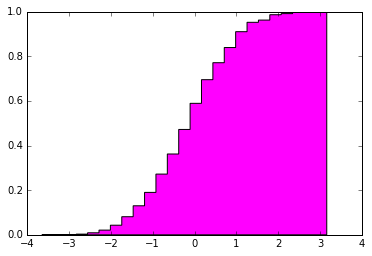

```python
# on crée un tableau avec des valeurs aléatoires obtenues
# avec une loi normale
valeurs=np.random.randn(1000)
plt.hist(valeurs ,
        25, # nombre de barres
        normed=True, # données normalisées
        cumulative=True, # histogramme cumulatif
        color='magenta', # couleur
        histtype='stepfilled' # type : bar,barstacked ,step,stepfilled
        )
plt.show()
```

### Deux histogramme sur la même figure

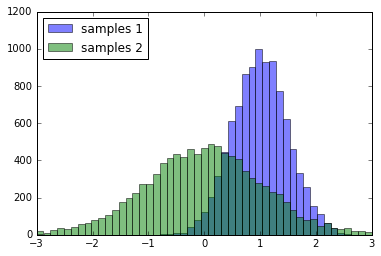

```python
samples_1 = np.random.normal(loc=1, scale=.5, size=10000)
samples_2 = np.random.standard_t(df=10, size=10000)
bins = np.linspace(-3, 3, 50)

# Définir un alpha et utiliser le même bins vu qu'on représente deux histogrammes
plt.hist(samples_1, bins=bins, alpha=0.5, label='samples 1')
plt.hist(samples_2, bins=bins, alpha=0.5, label='samples 2')
plt.legend(loc='upper left');
plt.show()
```

## Nuage de points

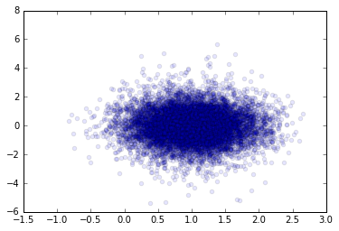

```python
plt.scatter(samples_1, samples_2, alpha=0.1);
plt.show()
```

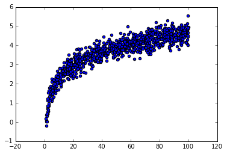

```python
# Create sample data, add some noise
x = np.random.uniform(1, 100, 1000)
y = np.log(x) + np.random.normal(0, .3, 1000)

plt.scatter(x, y)
plt.show()
```

## Graphes en coordonnées polaires

On utilise la commande polar :

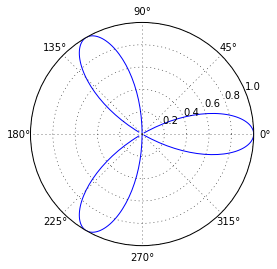

```python
theta=np.linspace(0,2*np.pi,500)
r=np.cos(3*theta)
plt.polar(theta,r)
plt.show()
```

## Figures et subplots

L’affichage avec **plt.show()** ouvrira une fenêtre pour chaque figure créée. Plus intéressant, on peut dans une même figure, créer plusieurs graphiques. On utilise pour cela la commande **subplot** sous la forme subplot(p,q,n) où (p,q) représente la taille du tableau des sous-graphiques et n la position dans ce tableau : si p = 2 et q = 3, alors on crée une grille de 6 graphiques (2 lignes et 3 colonnes) numérotés de 1 à 6.

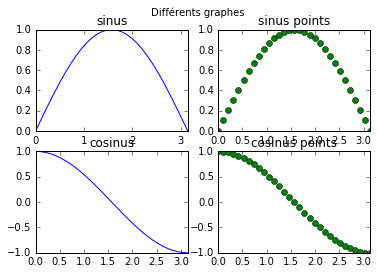

```python
x=np.linspace(0,np.pi,31)
plt.suptitle("Différents graphes") # le titre général

plt.subplot(2,2,1) # une grille 2x2 - premier graphique
plt.axis((0,np.pi,0,1))
y=np.sin(x)
plt.title('sinus')
plt.xticks([0,1,2,3])
plt.plot(x,y,"b-")

plt.subplot(2,2,2) # second graphique
plt.axis((0,np.pi,0,1))
plt.title('sinus points')
plt.plot(x,y,"go")

plt.subplot(2,2,3) # troisième graphique
y=np.cos(x)
plt.axis((0,np.pi,-1,1))
plt.title('cosinus')
plt.plot(x,y,"b-")

plt.subplot(2,2,4) # et le dernier
plt.axis((0,np.pi,-1,1))
plt.title('cosinus points')
plt.plot(x,y,"go")

plt.show() # on affiche le tout
```

On peut également utiliser la syntaxe suivante :

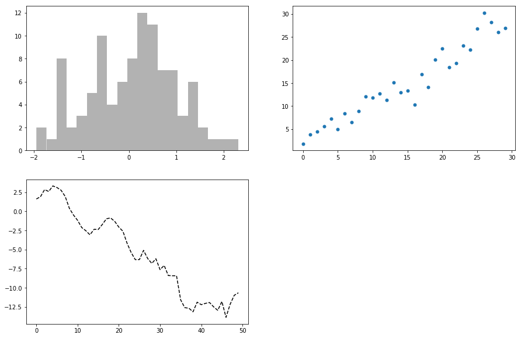

```python
from numpy.random import randn

fig = plt.figure(figsize=(15,10))
ax1 = fig.add_subplot(2,2,1)
ax2 = fig.add_subplot(2,2,2)
ax3 = fig.add_subplot(2,2,3)

# On peut compléter les instances de sous graphiques par leur contenu.
# Au passage, quelques autres exemples de graphes
ax1.hist(randn(100),bins=20,color='k',alpha=0.3)
ax2.scatter(np.arange(30),np.arange(30)+3*randn(30))
ax3.plot(randn(50).cumsum(),'k--')
```

**Faire attention :** Si aucune instance d'axes n'est précisée, la méthode plot est appliquée à la dernière instance créée.

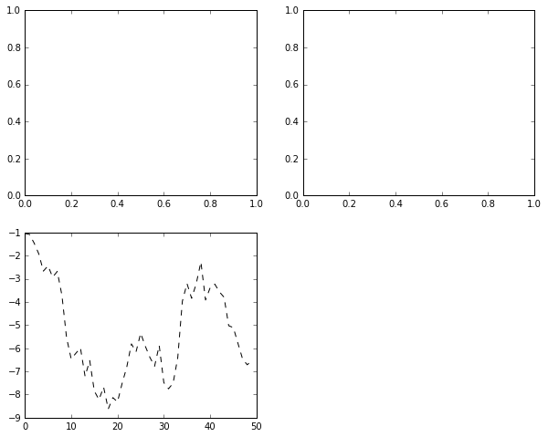

```python
from numpy.random import randn

fig = plt.figure(figsize=(10,8))
ax1 = fig.add_subplot(2,2,1)
ax2 = fig.add_subplot(2,2,2)
ax3 = fig.add_subplot(2,2,3)
plt.plot(randn(50).cumsum(),'k--')
plt.show()
```

## Affichage d’une matrice

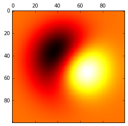

```python
import numpy as np
import matplotlib.pyplot as plt
def f(x,y):
    return (2*x-y**2+y)*np.exp(-x**2-y**2)
x=np.linspace(-2,2,100) # discrétisation de [-2,2]
y=np.linspace(-2,2,100) # idem
X,Y = np.meshgrid(x,y) # création de la grille complète
Z=f(X,Y) # on évalue f sur la grille
plt.matshow(Z,cmap='hot') # image avec les valeurs , style de couleurs 'hot'
plt.show()
```

## Pour aller plus loin

Pour explorer l'ensemble des catégories de graphiques possibles : [Gallery](http://matplotlib.org/gallery.html). Les plus utiles pour l'analyse de données : [scatter](http://matplotlib.org/examples/lines_bars_and_markers/scatter_with_legend.html), [scatterhist](http://matplotlib.org/examples/axes_grid/scatter_hist.html), [barchart](http://matplotlib.org/examples/pylab_examples/barchart_demo.html), [stackplot](http://matplotlib.org/examples/pylab_examples/stackplot_demo.html), [histogram](http://matplotlib.org/examples/statistics/histogram_demo_features.html), [cumulative distribution function](http://matplotlib.org/examples/statistics/histogram_demo_cumulative.html), [boxplot](http://matplotlib.org/examples/statistics/boxplot_vs_violin_demo.html), , [radarchart](http://matplotlib.org/examples/api/radar_chart.html).